# Learning Bayesian Data Analysis 1

# 1 What is This Stuff Called Probability?

## 1.1 Excercise 4.1

Point of excercises is also to get used to R

Built in library HairEyeColor Show the data in `HairEyeColor`

```r
show(HairEyeColor)
```

```
## , , Sex = Male
##
##        Eye
## Hair    Brown Blue Hazel Green
##   Black    32   11    10     3
##   Brown    53   50    25    15
##   Red      10   10     7     7
##   Blond     3   30     5     8
##
## , , Sex = Female
##
##        Eye
## Hair    Brown Blue Hazel Green
##   Black    36    9     5     2
##   Brown    66   34    29    14
##   Red      16    7     7     7
##   Blond     4   64     5     8
```

The data given is for both male and female. We sum the frequencies across sex.

```r
EyeHairFreq=apply(HairEyeColor, c("Eye","Hair"),sum)
show(EyeHairFreq)
```

```
##        Hair
## Eye     Black Brown Red Blond
##   Brown    68   119  26     7
##   Blue     20    84  17    94
##   Hazel    15    54  14    10
##   Green     5    29  14    16
```

Calculate Joint Proportions

```r
EyeHairProp=EyeHairFreq/sum(EyeHairFreq)
show(round(EyeHairProp,2))
```

```
##        Hair
## Eye     Black Brown  Red Blond
##   Brown  0.11  0.20 0.04  0.01
##   Blue   0.03  0.14 0.03  0.16
##   Hazel  0.03  0.09 0.02  0.02
##   Green  0.01  0.05 0.02  0.03
```

Marginal proportions across Hair and Sex

```r
HairFreq=apply(HairEyeColor, c("Hair"),sum)
HairProp=HairFreq/sum(HairFreq)
show(round(HairProp,2))
```

```
## Black Brown   Red Blond
##  0.18  0.48  0.12  0.21
```

Marginal proportions across Eye and Sex

```r
EyeFreq=apply(HairEyeColor, c("Eye"),sum)
EyeProp=EyeFreq/sum(EyeFreq)
show(round(EyeProp,2))
```

```
## Brown  Blue Hazel Green
##  0.37  0.36  0.16  0.11
```

Conditional probablity of Hair colours given Blue eyes. We normalise by the marginal probability of Blue eyes by `EyeProp["Blue"]`

```r
EyeHairProp["Blue",]/EyeProp["Blue"]
```

```
##      Black      Brown        Red      Blond
## 0.09302326 0.39069767 0.07906977 0.43720930
```

Probability of Hair colour given brown eyes

```
##      Black      Brown        Red      Blond
## 0.30909091 0.54090909 0.11818182 0.03181818
```

Probability of Eye colour given brown hair

**NOTE: the ‘EyeHairProp[,“Brown”]’ gives marginal probabilities along the column**

```r
EyeHairProp[,"Brown"]/HairProp["Brown"]
```

```
##     Brown      Blue     Hazel     Green
## 0.4160839 0.2937063 0.1888112 0.1013986
```

## 1.2 Excercise 4.2 Simulate biased coib with $p(H)=8$

Based on RunningProportion.R

### 1.2.1 Original Program

Specify the total number of flips, denoted N.

```r
N = 500
```

Specify underlying probability of heads.

```r
pHeads = 0.5
```

Flip a coin N times and compute the running proportion of heads at each flip.

Generate a random sample of N flips (heads=1, tails=0):

```r
flipSequence = sample( x=c(0,1), prob=c(1-pHeads,pHeads), size=N, replace=TRUE )
```

Compute the running proportion of heads:

```r
r = cumsum( flipSequence ) # Cumulative sum: Number of heads at each step.
n = 1:N                    # Number of flips at each step.
runProp = r / n            # Component by component division.
```

Graph the running proportion:

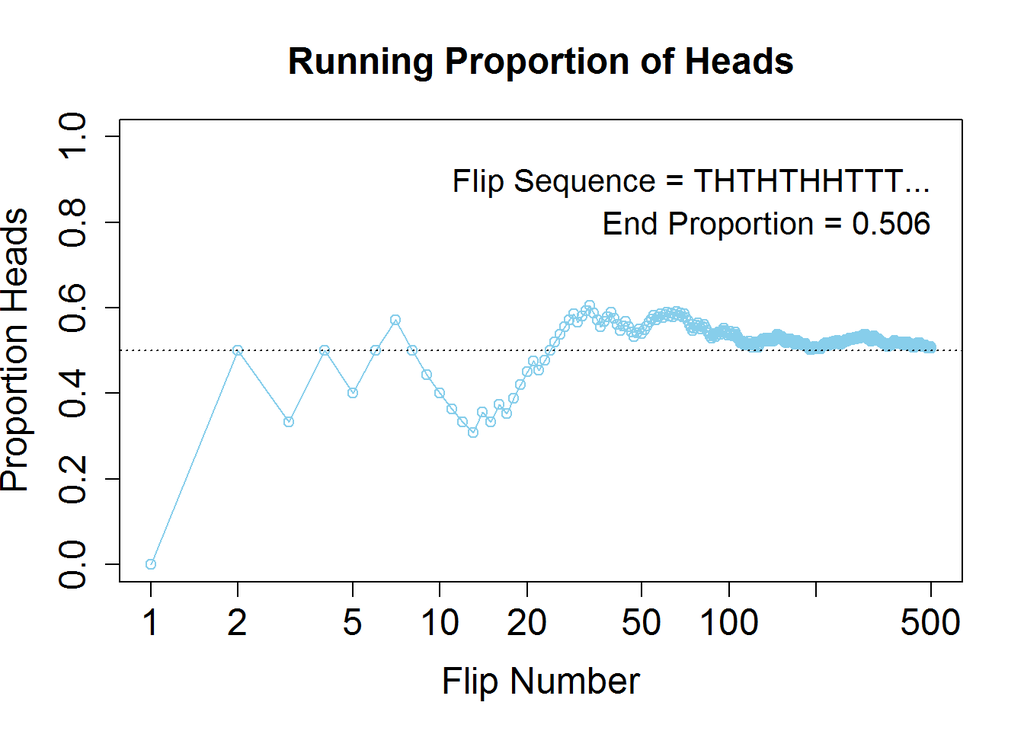

```r
plot( n , runProp , type="o" , log="x" , col="skyblue" ,
      xlim=c(1,N) , ylim=c(0.0,1.0) , cex.axis=1.5 ,
      xlab="Flip Number" , ylab="Proportion Heads" , cex.lab=1.5 ,
      main="Running Proportion of Heads" , cex.main=1.5 )
#Plot a dotted horizontal reference line:

abline( h=pHeads , lty="dotted" )
# Display the beginning of the flip sequence:
flipLetters = paste( c("T","H")[flipSequence[1:10]+1] , collapse="" )
displayString = paste0( "Flip Sequence = " , flipLetters , "..." )
text( N , .9 , displayString , adj=c(1,0.5) , cex=1.3 )
# Display the relative frequency at the end of the sequence.
text( N , .8 , paste("End Proportion =",runProp[N]) , adj=c(1,0.5) , cex=1.3 )
```

### 1.2.2 Modified Program

Specify the total number of flips, denoted N.

```r
N = 500
```

Specify underlying probability of heads.

```r
pHeads = 0.8
```

Flip a coin N times and compute the running proportion of heads at each flip.

Generate a random sample of N flips (heads=1, tails=0):

```r
flipSequence = sample( x=c(0,1), prob=c(1-pHeads,pHeads), size=N, replace=TRUE )
```

Compute the running proportion of heads:

```r
r = cumsum( flipSequence ) # Cumulative sum: Number of heads at each step.
n = 1:N                    # Number of flips at each step.
runProp = r / n            # Component by component division.
```

Graph the running proportion:

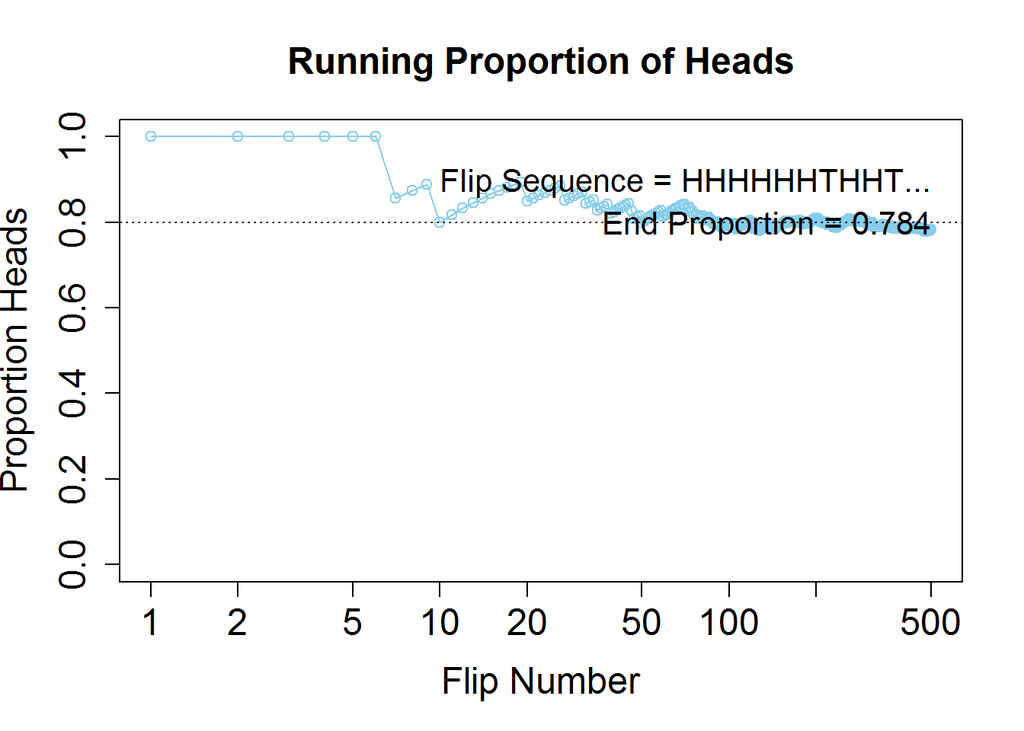

```r
plot( n , runProp , type="o" , log="x" , col="skyblue" ,
      xlim=c(1,N) , ylim=c(0.0,1.0) , cex.axis=1.5 ,
      xlab="Flip Number" , ylab="Proportion Heads" , cex.lab=1.5 ,
      main="Running Proportion of Heads" , cex.main=1.5 )
#Plot a dotted horizontal reference line:

abline( h=pHeads , lty="dotted" )
# Display the beginning of the flip sequence:
flipLetters = paste( c("T","H")[flipSequence[1:10]+1] , collapse="" )
displayString = paste0( "Flip Sequence = " , flipLetters , "..." )
text( N , .9 , displayString , adj=c(1,0.5) , cex=1.3 )
# Display the relative frequency at the end of the sequence.
text( N , .8 , paste("End Proportion =",runProp[N]) , adj=c(1,0.5) , cex=1.3 )
```

## 1.3 Ex 4.4

Simple Probability Density Function:

Consider Spinner with [0,1] scale on circumference. Biased such that: $p(x)=6x(1-x)$ over the interval $x\in [0,1]$

### 1.3.1 Plot this density function

Adapt from IntegralOfDensity.R

[figure not shown]

```r
#source("DBDA2E-utilities.R")
# Graph of normal probability density function, with comb of intervals.
# meanval = 0.0               # Specify mean of distribution.
# sdval = 0.2                 # Specify standard deviation of distribution.
xlow  = 0 # Specify low end of x-axis.
xhigh = 1 # Specify high end of x-axis.
dx = 0.1               # Specify interval width on x-axis
# Specify comb of points along the x axis:
newx = seq( from = xlow , to = xhigh , by = dx )
# Compute y values, i.e., probability density at each value of x:
y = (6*newx)*(1-newx)#( 1/(sdval*sqrt(2*pi)) ) * exp( -.5 * ((x-meanval)/sdval)^2 )
# Plot the function. "plot" draws the intervals. "lines" draws the bell curve.
#openGraph(width=7,height=5)
plot( newx , y , type="h" , lwd=1 , cex.axis=1.5
  , xlab="x" , ylab="p(x)" , cex.lab=1.5 ,
    , main="Normal Probability Density" , cex.main=1.5 )
lines( newx , y , lwd=3 ,  col="skyblue" )
```

```r
# Approximate the integral as the sum of width * height for each interval.
area = sum( dx * y )
# Display info in the graph.
# text( meanval-sdval , .9*max(y) , bquote( paste(mu ," = " ,.(meanval)) )
#       , adj=c(1,.5) , cex=1.5 )
# text( meanval-sdval , .75*max(y) , bquote( paste(sigma ," = " ,.(sdval)) )
#       , adj=c(1,.5) , cex=1.5 )
# text( meanval+sdval , .9*max(y) , bquote( paste(Delta , "x = " ,.(dx)) )
#       , adj=c(0,.5) , cex=1.5 )
# text( meanval+sdval , .75*max(y) ,
#       bquote(
#         paste( sum(,x,) , " " , Delta , "x p(x) = " , .(signif(area,3)) )
#       ) , adj=c(0,.5) , cex=1.5 )
```

## 1.4 Ex 4.5 Using normal curve to describe beliefs

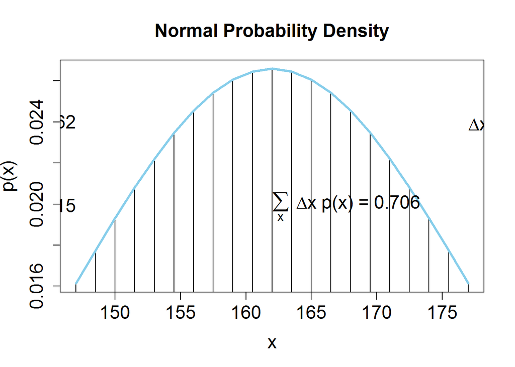

```r
# Graph of normal probability density function, with comb of intervals.
meanval = 162               # Specify mean of distribution.
sdval = 15               # Specify standard deviation of distribution.
xlow  = meanval - sdval # Specify low end of x-axis.
xhigh = meanval + sdval # Specify high end of x-axis.
dx = sdval/10               # Specify interval width on x-axis
# Specify comb of points along the x axis:
x = seq( from = xlow , to = xhigh , by = dx )
# Compute y values, i.e., probability density at each value of x:
y = ( 1/(sdval*sqrt(2*pi)) ) * exp( -.5 * ((x-meanval)/sdval)^2 )
# Plot the function. "plot" draws the intervals. "lines" draws the bell curve.
#openGraph(width=7,height=5)
plot( x , y , type="h" , lwd=1 , cex.axis=1.5
  , xlab="x" , ylab="p(x)" , cex.lab=1.5 ,
    , main="Normal Probability Density" , cex.main=1.5 )
lines( x , y , lwd=3 ,  col="skyblue" )
# Approximate the integral as the sum of width * height for each interval.
area = sum( dx * y )
# Display info in the graph.
text( meanval-sdval , .9*max(y) , bquote( paste(mu ," = " ,.(meanval)) )
      , adj=c(1,.5) , cex=1.5 )
text( meanval-sdval , .75*max(y) , bquote( paste(sigma ," = " ,.(sdval)) )
      , adj=c(1,.5) , cex=1.5 )
text( meanval+sdval , .9*max(y) , bquote( paste(Delta , "x = " ,.(dx)) )
      , adj=c(0,.5) , cex=1.5 )
text( meanval , .75*max(y) ,
      bquote(
        paste( sum(,x,) , " " , Delta , "x p(x) = " , .(signif(area,3)) )
      ) , adj=c(0,.5) , cex=1.5 )
```

```r
# Save the plot to an EPS file.
#saveGraph( file = "IntegralOfDensity" , type="eps" )
```